# Guía Modelos Lineales Mixtos

Curso Introducción al Análisis de datos con R para la acuicultura

Dr. José A. Gallardo y Dra. María Angélica Rueda.

Pontificia Universidad Católica de Valparaíso  
jose.gallardo@pucv.cl

30 July 2021

### MODELOS LINEALES MIXTOS

Los modelos lineales mixtos (MLM) son una generalización del modelo lineal de regresión clásico, contemplando la posible existencia de observaciones correlacionadas (ej. Medidas repetidas en el mismo individuo) o con variabilidad heterogénea, vinculadas a la presencia de factores aleatorios.

**Efecto fijo**: Los efectos fijos solo estiman medias de las variables predictoras.

**Efecto aleatorio**: Los efectos aleatorios estiman varianzas.

Caracteristicas de un modelo lineal mixto (MLM)

1). El MLM está conformado por efectos fijos y efectos aleatorios.

2). La variable respuesta debe tener ditribución normal.

3). Existencia de observaciones correlacionadas.

4). Puede existir heterogeneidad de varianzas.

Incumplimiento de supuestos (1 y 3):

1. Hay observaciones correlacionadas.
2. Los residuos se distribuyen **normalmente**.
3. No hay homogeneidad de varianzas.

#### **Objetivos de aprendizaje**

Los objetivos de aprendizaje de esta guía son:

**1**. - Identificar efectos fijos y efectos aleatorios.

**3**. - Ajustar modelos lineales mixtos.

**3**. - Realizar gráficas avanzadas con ggplot2.

**4**. - Elaborar un reporte dinámico en formato pdf con **[Rmarkdown](https://rmarkdown.rstudio.com/)**.

## ESTUDIO DE CASO: BLACK PORGY

En este estudio de caso trabajaremos con un set de datos de 120 observaciones simuladas de black porgy.

La variable respuesta se denomina **Weight** y las variables predictoras **Diet**, **Dosis** como efectos fijos y **Family** como efecto aleatorio. Todas ellas son variables predictoras cualitativas.

### **Ejercicio 1.** Elaborar y configurar Reporte en formato .Rmd

Elabore un documento .Rmd y configure su reporte para exportar en .pdf. Instale solo las librerías que utilice para el análisis de los datos.

```r
knitr::opts_chunk$set(echo = TRUE)
library(readxl)
library(ggplot2)
library(dplyr)
library(multcomp)
library(psych)
library(car)
library(nlme)
library(lme4)
library(readr)
library(lmtest)
```

Ejecute cada uno de los siguientes ejercicios en uno o más bloques de códigos diferentes. Sea ordenado y documente su reporte adecuadamente.

### **Ejercicio 2.** Exploratorio set de datos black_porgy

Importe el set de datos **black_porgy.xls** y realice un análisis exploratorio de datos.

Incluya:

**a).** Resumen estadístico de todas las variables.

```r
black_porgy <- read_excel("black_porgy.xlsx")
summary(black_porgy)
```

```
##        ID             Weight         Dosis               Tank
##  Min.   :  1.00   Min.   :38.00   Length:120         Length:120
##  1st Qu.: 30.75   1st Qu.:57.00   Class :character   Class :character
##  Median : 60.50   Median :63.00   Mode  :character   Mode  :character
##  Mean   : 60.50   Mean   :63.24
##  3rd Qu.: 90.25   3rd Qu.:70.00
##  Max.   :120.00   Max.   :85.00
##      Family          Diet
##  Min.   : 1.00   Length:120
##  1st Qu.: 6.75   Class :character
##  Median :12.50   Mode  :character
##  Mean   :12.50
##  3rd Qu.:18.25
##  Max.   :24.00
```

**b).** Transforme las variables Dosis, Diet y Tank en factores. Luego, pida el summary() de la base de datos black_porgy.

```r
black_porgy$Dosis <- as.factor(black_porgy$Dosis)
black_porgy$Diet <- as.factor(black_porgy$Diet)
black_porgy$Tank <- as.factor(black_porgy$Tank)
black_porgy$Family <- as.factor(black_porgy$Family)
black_porgy$ID <- as.factor(black_porgy$ID)
summary(black_porgy)
```

```
##        ID          Weight      Dosis        Tank        Family   Diet
##  1      :  1   Min.   :38.00   CS :40   Tank_1:30   1      : 5   d1:30
##  2      :  1   1st Qu.:57.00   T20:40   Tank_2:30   2      : 5   d2:30
##  3      :  1   Median :63.00   T40:40   Tank_3:30   3      : 5   d3:30
##  4      :  1   Mean   :63.24            Tank_4:30   4      : 5   d4:30
##  5      :  1   3rd Qu.:70.00                        5      : 5
##  6      :  1   Max.   :85.00                        6      : 5
##  (Other):114                                        (Other):90
```

**c).** Realice el exploratorio de los datos

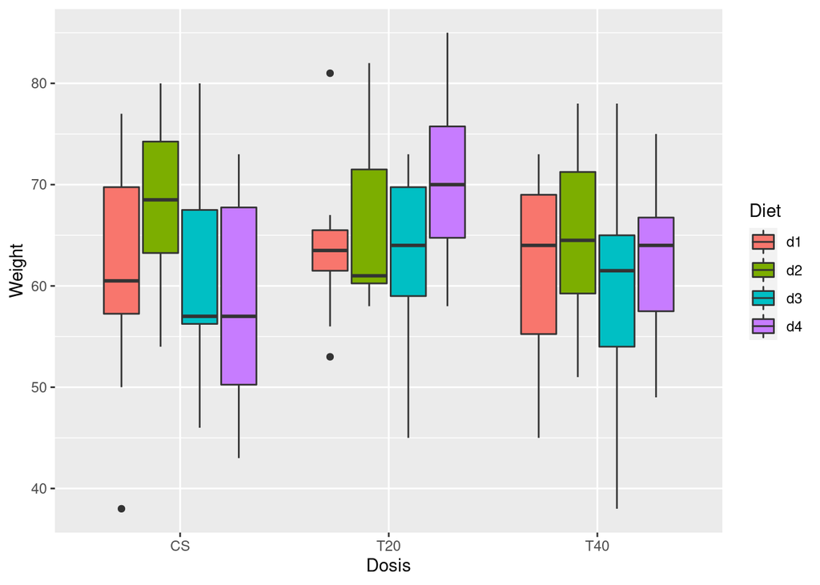

```r
ggplot(data = black_porgy,aes(x= Dosis, y = Weight, fill=Diet)) +
  geom_boxplot() + theme(legend.position = 'right')
```

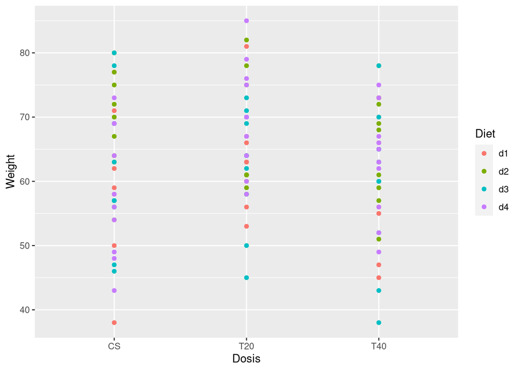

```r
p <- ggplot(data = black_porgy,aes(x = Dosis,y = Weight))
p + geom_point(aes(colour = Diet)) + stat_smooth(se = FALSE)
```

**d).** Histograma de la variable respuesta **Weight**.

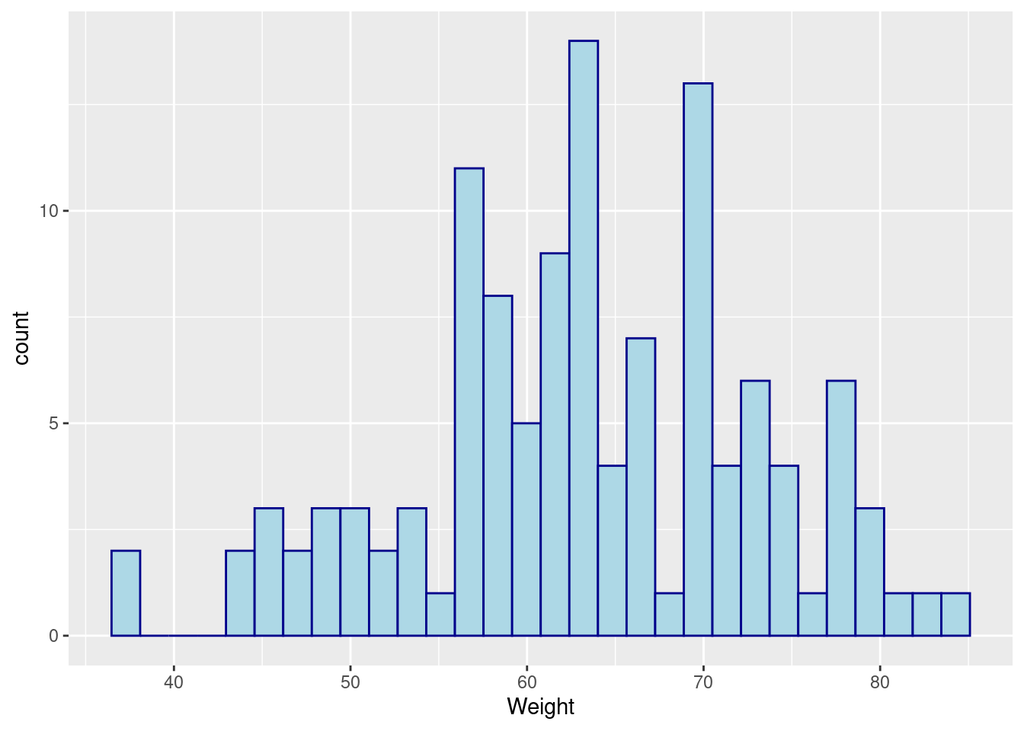

```r
ggplot(black_porgy, aes(x=Weight))+
  geom_histogram(color="darkblue", fill="lightblue")
```

### **Ejercicio 3.** Modelo de efectos fijos

**a).** Ajuste un modelo donde la variable respuesta sea **Weight** y como efectos fijos del modelo las variables *Dosis* y *Diet*. Use la función **lm()**, **summary()**.

Interprete los resultados del modelo ajustado y responda las siguientes preguntas:  
- ¿El efecto fijo Dosis es estadísticamente significativo? - ¿El efecto fijo Diet es estadísticamente significativo? - ¿Cuál es la bondad de ajuste del modelo $R^2$ ajustado?

```r
mod.1 <- lm(Weight ~ Diet + Dosis, data = black_porgy)

pander::pander(summary(mod.1), caption = "Modelo de efectos fijos de los datos black_porgy")
```

|  | Estimate | Std. Error | t value | Pr(>\|t\|) |
| --- | --- | --- | --- | --- |
| **(Intercept)** | 60.87 | 2.169 | 28.06 | 5.178e-53 |
| **Dietd2** | 4 | 2.505 | 1.597 | 0.1131 |
| **Dietd3** | -1.067 | 2.505 | -0.4258 | 0.671 |
| **Dietd4** | 1.767 | 2.505 | 0.7053 | 0.4821 |
| **DosisT20** | 3.55 | 2.169 | 1.636 | 0.1045 |
| **DosisT40** | 0.025 | 2.169 | 0.01152 | 0.9908 |

Modelo de efectos fijos de los datos black_porgy **b).** Ajuste un modelo donde la variable respuesta sea **Weight**, como efecto fijo del modelo la interacción entre *Diet:Dosis*. Use la función **lm()**, **summary()**.

| Observations | Residual Std. Error | $R^2$ | Adjusted $R^2$ |
| --- | --- | --- | --- |
| 120 | 9.702 | 0.06743 | 0.02652 |

```r
mod.1.int <- lm(Weight ~ Diet:Dosis, data = black_porgy)

pander::pander(summary(mod.1.int), caption = "Modelo de efectos fijos con iteracción de los datos coblack_porgy")
```

|  | Estimate | Std. Error | t value | Pr(>\|t\|) |
| --- | --- | --- | --- | --- |
| **(Intercept)** | 62.8 | 3.069 | 20.46 | 5.894e-39 |
| **Dietd1:DosisCS** | -1.7 | 4.34 | -0.3917 | 0.696 |
| **Dietd2:DosisCS** | 5 | 4.34 | 1.152 | 0.2518 |
| **Dietd3:DosisCS** | -1.8 | 4.34 | -0.4147 | 0.6791 |
| **Dietd4:DosisCS** | -4.5 | 4.34 | -1.037 | 0.3021 |
| **Dietd1:DosisT20** | 1 | 4.34 | 0.2304 | 0.8182 |
| **Dietd2:DosisT20** | 2.8 | 4.34 | 0.6452 | 0.5202 |
| **Dietd3:DosisT20** | -0.2 | 4.34 | -0.04608 | 0.9633 |
| **Dietd4:DosisT20** | 7.6 | 4.34 | 1.751 | 0.08276 |
| **Dietd1:DosisT40** | -1.5 | 4.34 | -0.3456 | 0.7303 |
| **Dietd2:DosisT40** | 2 | 4.34 | 0.4608 | 0.6458 |
| **Dietd3:DosisT40** | -3.4 | 4.34 | -0.7834 | 0.4351 |

Modelo de efectos fijos con iteracción de los datos coblack_porgy

| Observations | Residual Std. Error | $R^2$ | Adjusted $R^2$ |
| --- | --- | --- | --- |
| 120 | 9.704 | 0.116 | 0.02598 |

### **Ejercicio 4.** Modelo lineal mixto

**a).** Ajuste un modelo donde la variable respuesta sea **Weight**, como efectos fijos del modelo las variables *Diet* y *Dosis* y como efecto aleatorio **Family**. Use la función **lmer()**, **summary()**.

```r
mod.2 <- lmer(Weight ~ Diet + Dosis + (1|Family), data = black_porgy)
summary(mod.2)
```

```
## Linear mixed model fit by REML ['lmerMod']
## Formula: Weight ~ Diet + Dosis + (1 | Family)
##    Data: black_porgy
##
## REML criterion at convergence: 861.2
##
## Scaled residuals:
##     Min      1Q  Median      3Q     Max
## -2.3551 -0.6960  0.0244  0.7454  2.1214
##
## Random effects:
##  Groups   Name        Variance Std.Dev.
##  Family   (Intercept)  3.688   1.921
##  Residual             91.213   9.551
## Number of obs: 120, groups:  Family, 24
##
## Fixed effects:
##             Estimate Std. Error t value
## (Intercept)   60.875      2.342  25.998
## Dietd2         4.000      2.704   1.479
## Dietd3        -1.067      2.704  -0.395
## Dietd4         1.767      2.704   0.653
## DosisT20       3.550      2.342   1.516
## DosisT40       0.025      2.342   0.011
##
## Correlation of Fixed Effects:
##          (Intr) Dietd2 Dietd3 Dietd4 DssT20
## Dietd2   -0.577
## Dietd3   -0.577  0.500
## Dietd4   -0.577  0.500  0.500
## DosisT20 -0.500  0.000  0.000  0.000
## DosisT40 -0.500  0.000  0.000  0.000  0.500
```

**b).** Ajuste un modelo donde la variable respuesta sea **Weight**, como efectos fijos del modelo las variables *Diet*,*Dosis*, la interacción **Diet:Dosis** y como efecto aleatorio **Family**. Use la función **lmer()**, **summary()**.

```r
mod.2.int <- lmer(Weight ~ Diet + Dosis + Diet:Dosis + (1|Family), data = black_porgy)
summary(mod.2.int)
```

```
## Linear mixed model fit by REML ['lmerMod']
## Formula: Weight ~ Diet + Dosis + Diet:Dosis + (1 | Family)
##    Data: black_porgy
##
## REML criterion at convergence: 824.6
##
## Scaled residuals:
##      Min       1Q   Median       3Q      Max
## -2.35948 -0.58165 -0.04188  0.76874  2.02733
##
## Random effects:
##  Groups   Name        Variance Std.Dev.
##  Family   (Intercept)  5.336   2.310
##  Residual             91.213   9.551
## Number of obs: 120, groups:  Family, 24
##
## Fixed effects:
##                 Estimate Std. Error t value
## (Intercept)       61.100      3.434  17.795
## Dietd2             6.700      4.856   1.380
## Dietd3            -0.100      4.856  -0.021
## Dietd4            -2.800      4.856  -0.577
## DosisT20           2.700      4.856   0.556
## DosisT40           0.200      4.856   0.041
## Dietd2:DosisT20   -4.900      6.867  -0.714
## Dietd3:DosisT20   -1.100      6.867  -0.160
## Dietd4:DosisT20    9.400      6.867   1.369
## Dietd2:DosisT40   -3.200      6.867  -0.466
## Dietd3:DosisT40   -1.800      6.867  -0.262
## Dietd4:DosisT40    4.300      6.867   0.626
##
## Correlation of Fixed Effects:
##             (Intr) Dietd2 Dietd3 Dietd4 DssT20 DssT40 D2:DT2 D3:DT2 D4:DT2
## Dietd2      -0.707
## Dietd3      -0.707  0.500
## Dietd4      -0.707  0.500  0.500
## DosisT20    -0.707  0.500  0.500  0.500
## DosisT40    -0.707  0.500  0.500  0.500  0.500
## Dtd2:DssT20  0.500 -0.707 -0.354 -0.354 -0.707 -0.354
## Dtd3:DssT20  0.500 -0.354 -0.707 -0.354 -0.707 -0.354  0.500
## Dtd4:DssT20  0.500 -0.354 -0.354 -0.707 -0.707 -0.354  0.500  0.500
## Dtd2:DssT40  0.500 -0.707 -0.354 -0.354 -0.354 -0.707  0.500  0.250  0.250
## Dtd3:DssT40  0.500 -0.354 -0.707 -0.354 -0.354 -0.707  0.250  0.500  0.250
## Dtd4:DssT40  0.500 -0.354 -0.354 -0.707 -0.354 -0.707  0.250  0.250  0.500
##             D2:DT4 D3:DT4
## Dietd2
## Dietd3
## Dietd4
## DosisT20
## DosisT40
## Dtd2:DssT20
## Dtd3:DssT20
## Dtd4:DssT20
## Dtd2:DssT40
## Dtd3:DssT40  0.500
## Dtd4:DssT40  0.500  0.500
```

### **Ejercicio 5.** Comparación y selección de modelos

**a).** Realice la comparación de modelos con la función anova(). Comparar los dos modelos que se hicieron con lm() y por aparte realice la comparación de los dos modelos que se hicieron con lmer().

- ¿Cuál es el mejor modelo?
- ¿Hubo mejoría al incorporar el efecto aleatorio de familia?

```r
anova(mod.1, mod.1.int)
```

```
## Analysis of Variance Table
##
## Model 1: Weight ~ Diet + Dosis
## Model 2: Weight ~ Diet:Dosis
##   Res.Df   RSS Df Sum of Sq      F Pr(>F)
## 1    114 10730
## 2    108 10171  6    559.08 0.9894 0.4362
```

```r
anova(mod.2, mod.2.int)
```

```
## refitting model(s) with ML (instead of REML)
```

```
## Data: black_porgy
## Models:
## mod.2: Weight ~ Diet + Dosis + (1 | Family)
## mod.2.int: Weight ~ Diet + Dosis + Diet:Dosis + (1 | Family)
##           npar    AIC    BIC  logLik deviance  Chisq Df Pr(>Chisq)
## mod.2        8 895.74 918.04 -439.87   879.74
## mod.2.int   14 901.32 940.35 -436.66   873.32 6.4212  6     0.3777
```